# Happiness Report (2019)

## 1. Introduction (Exploratory Data Analysis)

### a. Introduction (strategy)

1. Assess the general characteristics of the data set
2. Examine descriptive statistics for each variable
3. Visualize variable relations
4. Where possible, investigate data anomalies
5. Examine relations between key variables

### b. Summarizing numerical data

```r
library(ggplot2)
library(caTools)
library(dplyr)
library(broom)
library(ggpubr)
```

```r
# Importing the data set
data_2019 <- read.csv('2019_report.csv')
```

```r
str(data_2019)
```

```
## 'data.frame':    138 obs. of  10 variables:
##  $ country          : chr  "Denmark" "Switzerland" "Iceland" "Norway" ...
##  $ happiness_score  : num  7.53 7.51 7.5 7.5 7.41 ...
##  $ gdp_per_capita   : num  1.44 1.53 1.43 1.58 1.41 ...
##  $ family           : num  1.16 1.15 1.18 1.13 1.13 ...
##  $ health           : num  0.795 0.863 0.867 0.796 0.811 ...
##  $ freedom          : num  0.579 0.586 0.566 0.596 0.571 ...
##  $ government_trust : num  0.445 0.412 0.15 0.358 0.41 ...
##  $ generosity       : num  0.362 0.281 0.477 0.379 0.255 ...
##  $ dystopia_residual: num  2.74 2.69 2.83 2.66 2.83 ...
##  $ continent        : chr  "Europe" "Europe" "Europe" "Europe" ...
```

```r
head(data_2019)
```

|  | country | happiness_score | gdp_per_capita | family | health | freedom | government_trust | generosity | dystopia_residual | continent |
| --- | --- | --- | --- | --- | --- | --- | --- | --- | --- | --- |
| 1 | Denmark | 7.526 | 1.44178 | 1.16374 | 0.79504 | 0.57941 | 0.44453 | 0.36171 | 2.73939 | Europe |
| 2 | Switzerland | 7.509 | 1.52733 | 1.14524 | 0.86303 | 0.58557 | 0.41203 | 0.28083 | 2.69463 | Europe |
| 3 | Iceland | 7.501 | 1.42666 | 1.18326 | 0.86733 | 0.56624 | 0.14975 | 0.47678 | 2.83137 | Europe |
| 4 | Norway | 7.498 | 1.57744 | 1.12690 | 0.79579 | 0.59609 | 0.35776 | 0.37895 | 2.66465 | Europe |
| 5 | Finland | 7.413 | 1.40598 | 1.13464 | 0.81091 | 0.57104 | 0.41004 | 0.25492 | 2.82596 | Europe |
| 6 | Canada | 7.404 | 1.44015 | 1.09610 | 0.82760 | 0.57370 | 0.31329 | 0.44834 | 2.70485 | North America |

```r
# summarizing the data
num_data <- data_2019[, c(2,3,4,5,6,7,8,9)]
summary(num_data)
```

```
##  happiness_score gdp_per_capita        family           health
##  Min.   :2.905   Min.   :0.05661   Min.   :0.0000   Min.   :0.0000
##  1st Qu.:4.407   1st Qu.:0.67472   1st Qu.:0.6423   1st Qu.:0.4097
##  Median :5.351   Median :1.03235   Median :0.8609   Median :0.6161
##  Mean   :5.409   Mean   :0.95958   Mean   :0.8052   Mean   :0.5668
##  3rd Qu.:6.347   3rd Qu.:1.27435   3rd Qu.:1.0326   3rd Qu.:0.7300
##  Max.   :7.526   Max.   :1.69752   Max.   :1.1833   Max.   :0.9472
##     freedom       government_trust    generosity     dystopia_residual
##  Min.   :0.0432   Min.   :0.00000   Min.   :0.0000   Min.   :0.9168
##  1st Qu.:0.2587   1st Qu.:0.05518   1st Qu.:0.1446   1st Qu.:2.0521
##  Median :0.3913   Median :0.09586   Median :0.2148   Median :2.3009
##  Mean   :0.3719   Mean   :0.13258   Mean   :0.2367   Mean   :2.3365
##  3rd Qu.:0.4722   3rd Qu.:0.17387   3rd Qu.:0.3032   3rd Qu.:2.6697
##  Max.   :0.6085   Max.   :0.50521   Max.   :0.8197   Max.   :3.5591
```

### c. Anomalies in numerical data investigation

**The dots in the boxplots below show the outlier values**

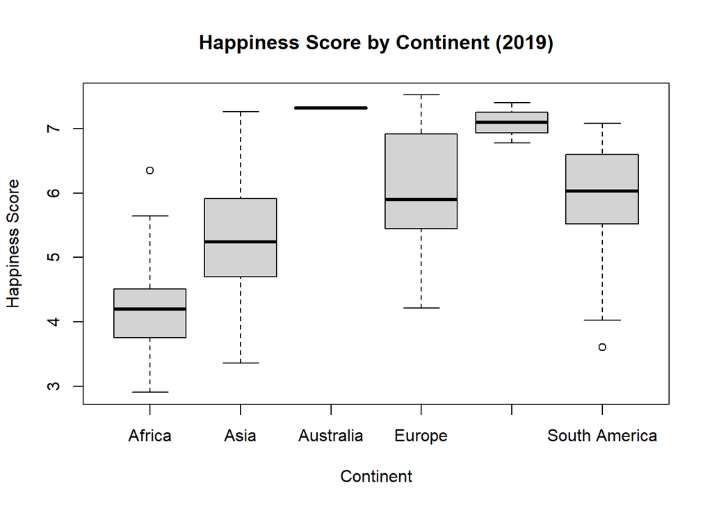

```r
plot(factor(data_2019$continent), data_2019$happiness_score, xlab='Continent',
     ylab='Happiness Score', main='Happiness Score by Continent (2019)')
```

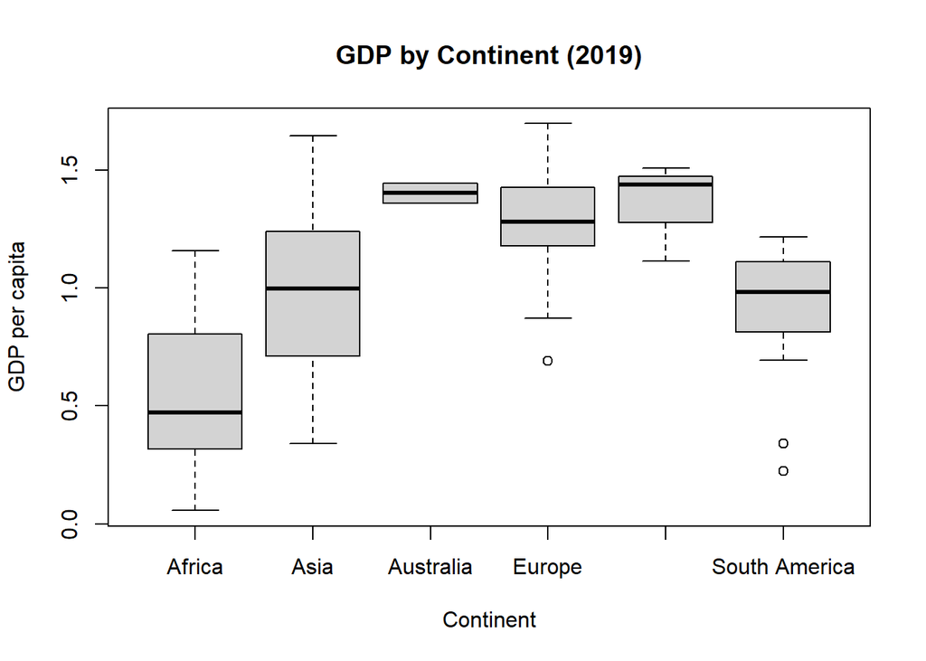

```r
plot(factor(data_2019$continent), data_2019$gdp_per_capita, xlab='Continent',
     ylab='GDP per capita', main='GDP by Continent (2019)')
```

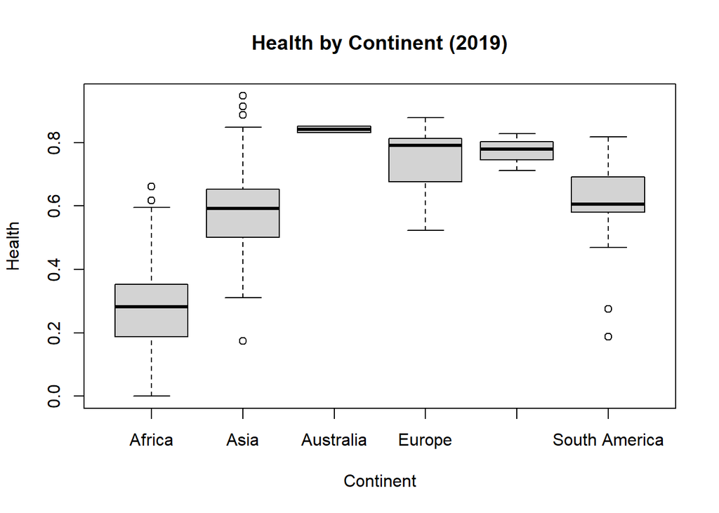

```r
plot(factor(data_2019$continent), data_2019$health, xlab='Continent',
     ylab='Health', main='Health by Continent (2019)')
```

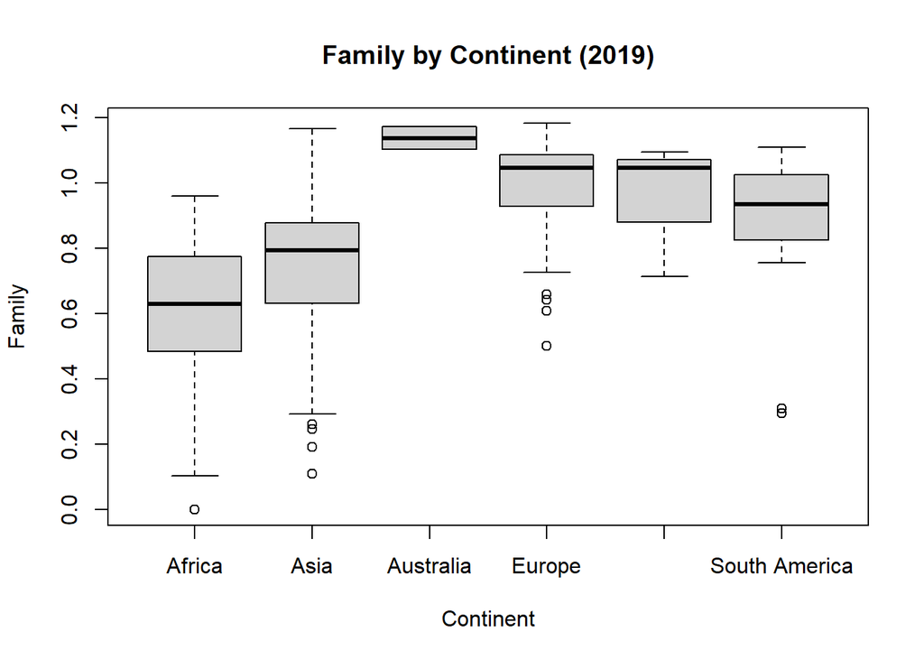

```r
plot(factor(data_2019$continent), data_2019$family, xlab='Continent',
     ylab='Family', main='Family by Continent (2019)')
```

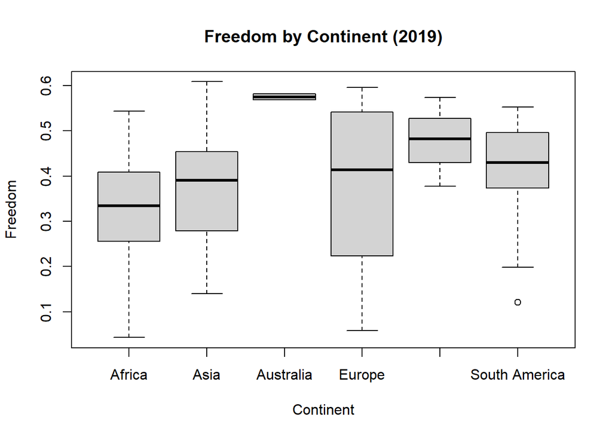

```r
plot(factor(data_2019$continent), data_2019$freedom, xlab='Continent',
     ylab='Freedom', main='Freedom by Continent (2019)')
```

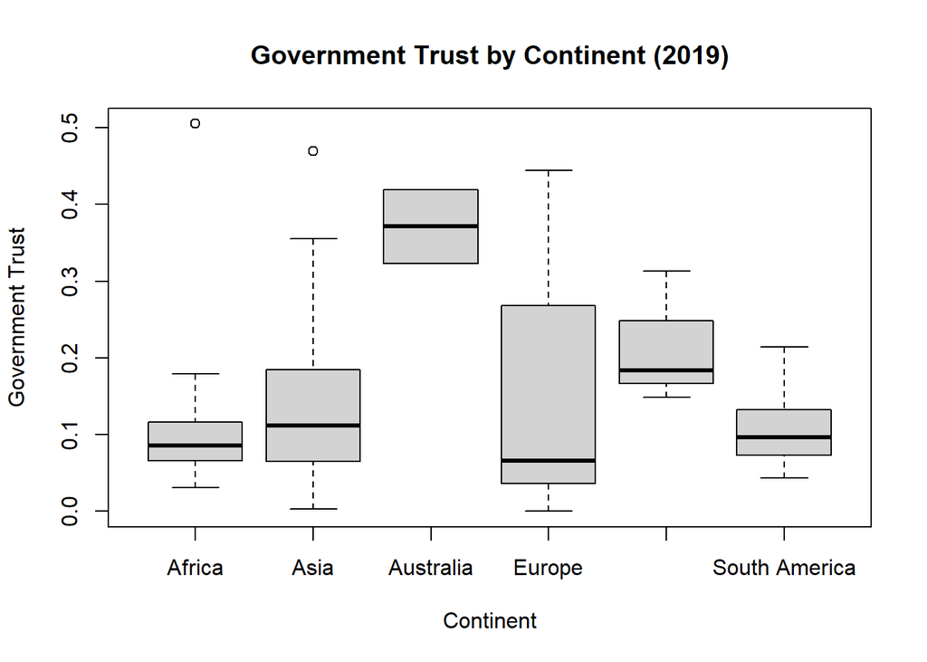

```r
plot(factor(data_2019$continent), data_2019$government_trust, xlab='Continent',
     ylab='Government Trust', main='Government Trust by Continent (2019)')
```

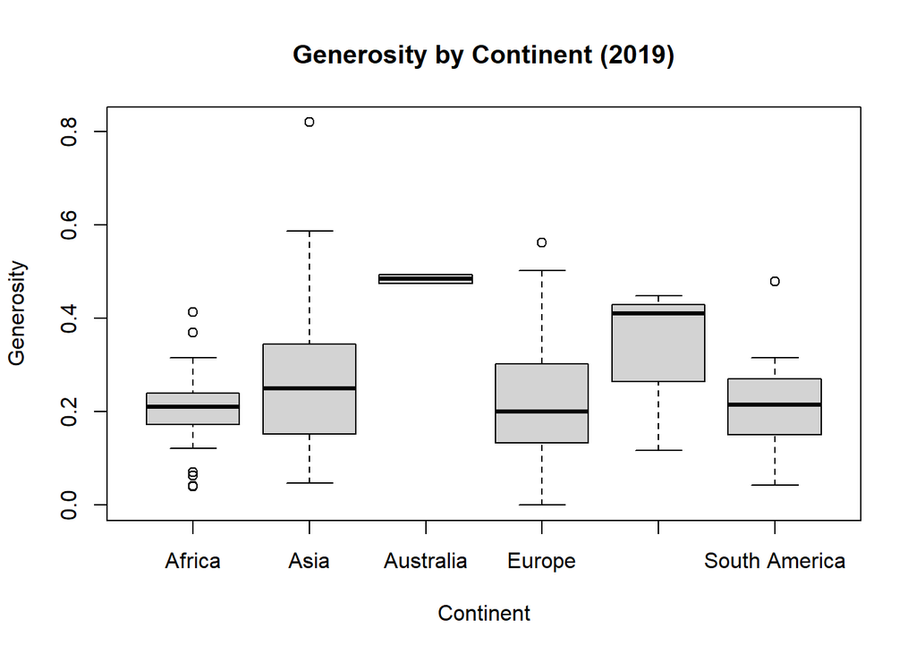

```r
plot(factor(data_2019$continent), data_2019$generosity, xlab='Continent',
     ylab='Generosity', main='Generosity by Continent (2019)')
```

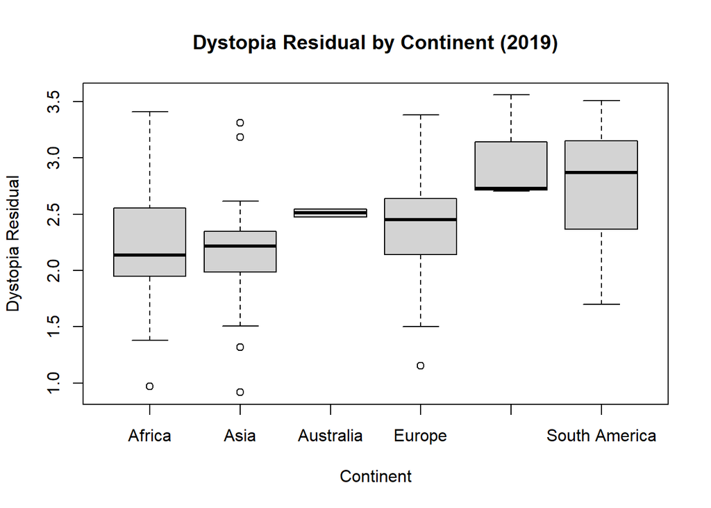

```r
plot(factor(data_2019$continent), data_2019$dystopia_residual, xlab='Continent',
     ylab='Dystopia Residual', main='Dystopia Residual by Continent (2019)')
```

```r
# checking for any missing values
any(is.na(data_2019))
```

```
## [1] FALSE
```

### d. Visualization between variables relations

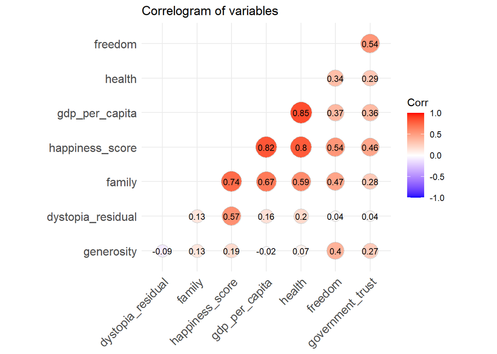

```r
# plotting variable relations (2019)

library(ggcorrplot)

num_data <- data_2019[, c(2,3,4,5,6,7,8,9)]

ggcorrplot(cor(num_data), hc.order = TRUE, type = "lower", lab = TRUE, lab_size = 3, method="circle", colors = c("blue", "white", "red"), outline.color = "gray", show.legend = TRUE, show.diag = FALSE, title="Correlogram of variables")
```

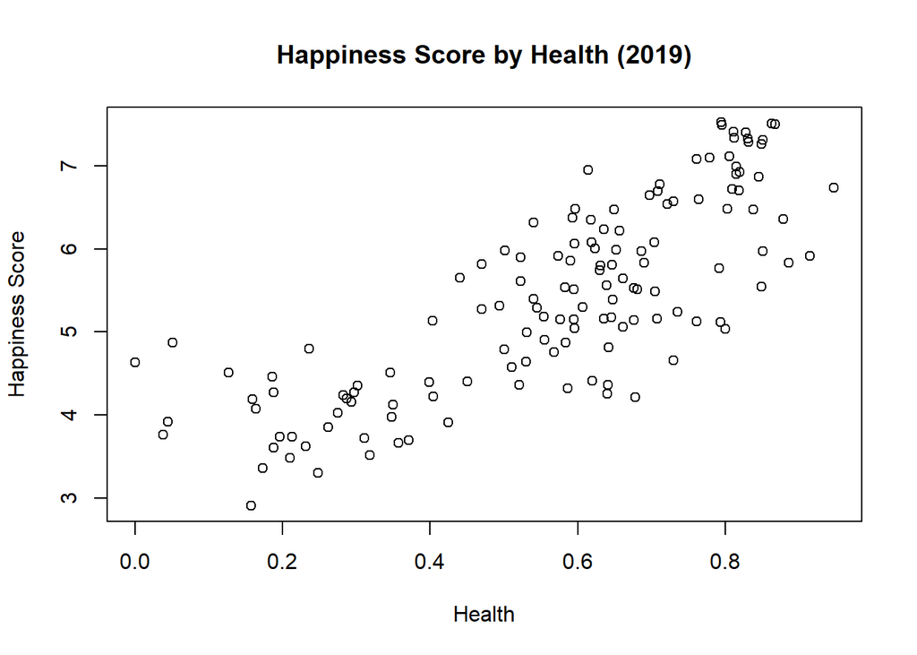

```r
plot(data_2019$health, data_2019$happiness_score, xlab='Health',
     ylab='Happiness Score', main='Happiness Score by Health (2019)')
```

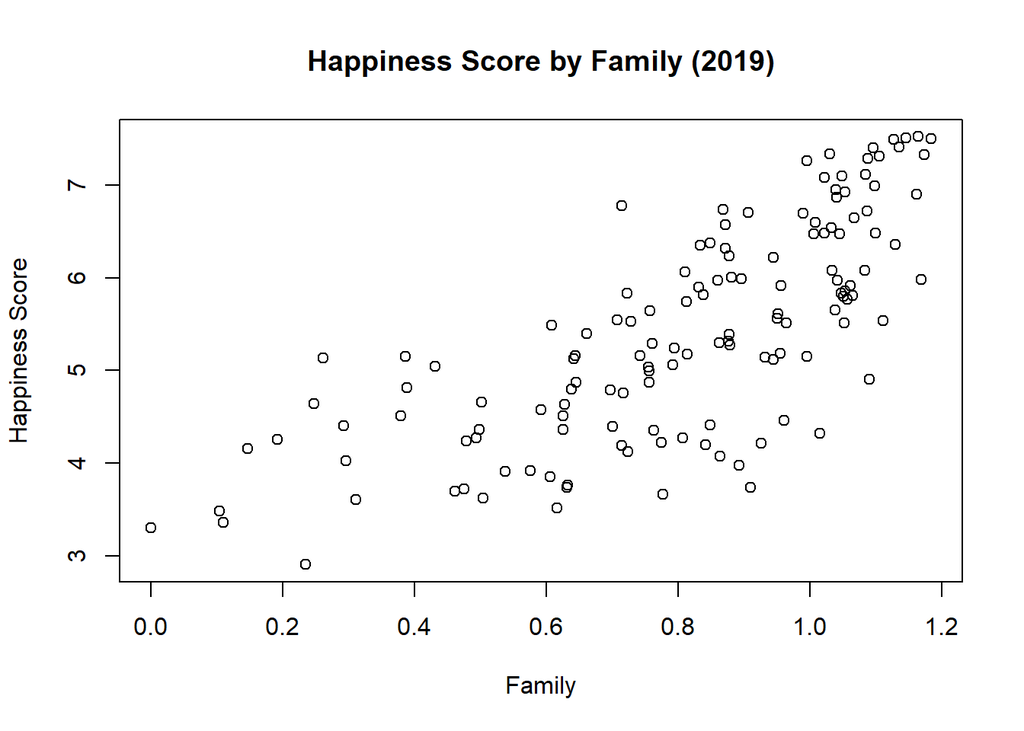

```r
plot(data_2019$family, data_2019$happiness_score, xlab='Family',
     ylab='Happiness Score', main='Happiness Score by Family (2019)')
```

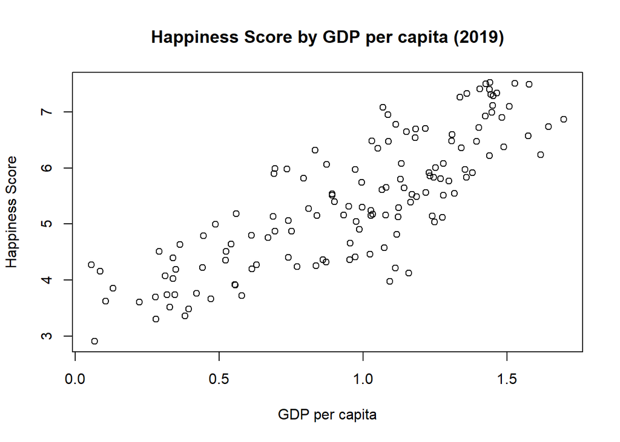

```r
plot(data_2019$gdp_per_capita, data_2019$happiness_score, xlab='GDP per capita',
     ylab='Happiness Score', main='Happiness Score by GDP per capita (2019)')
```

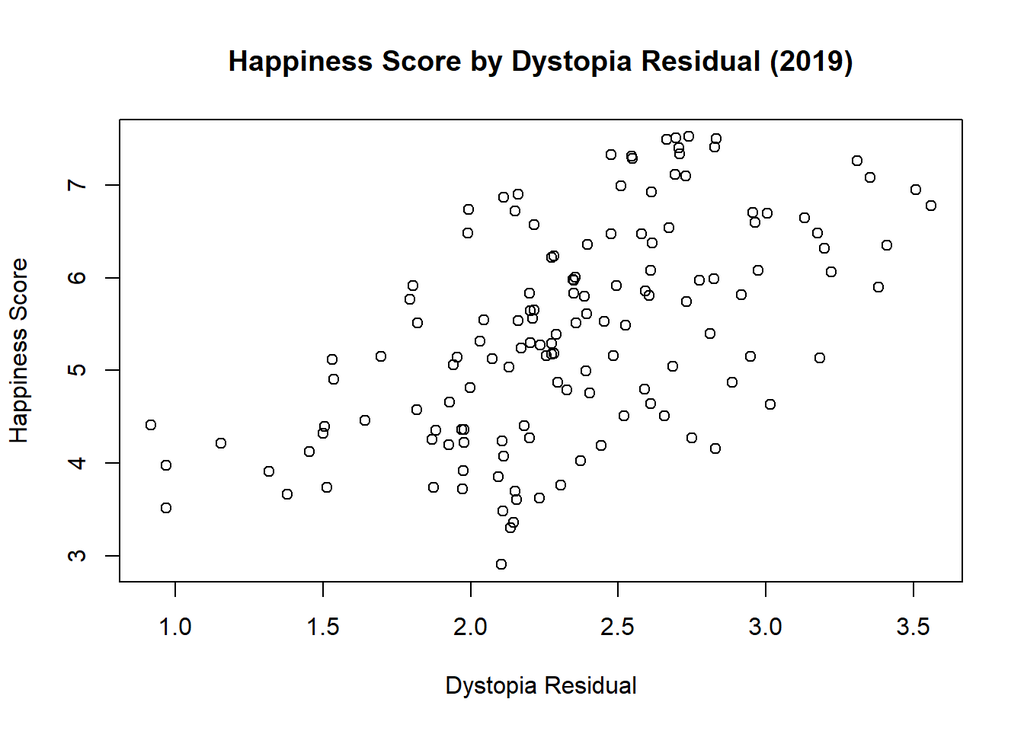

```r
plot(data_2019$dystopia_residual, data_2019$happiness_score, xlab='Dystopia Residual',
     ylab='Happiness Score', main='Happiness Score by Dystopia Residual (2019)')
```

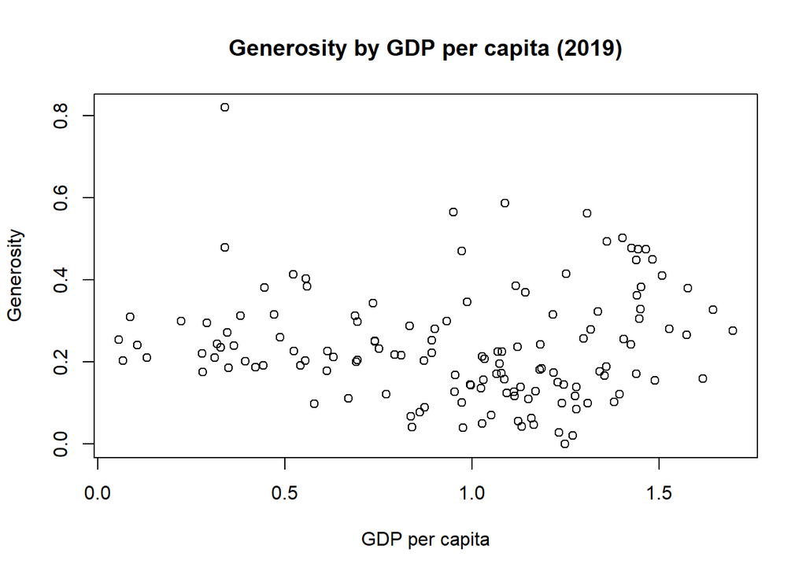

```r
plot(data_2019$gdp_per_capita, data_2019$generosity, xlab='GDP per capita',
     ylab='Generosity', main='Generosity by GDP per capita (2019)')
```

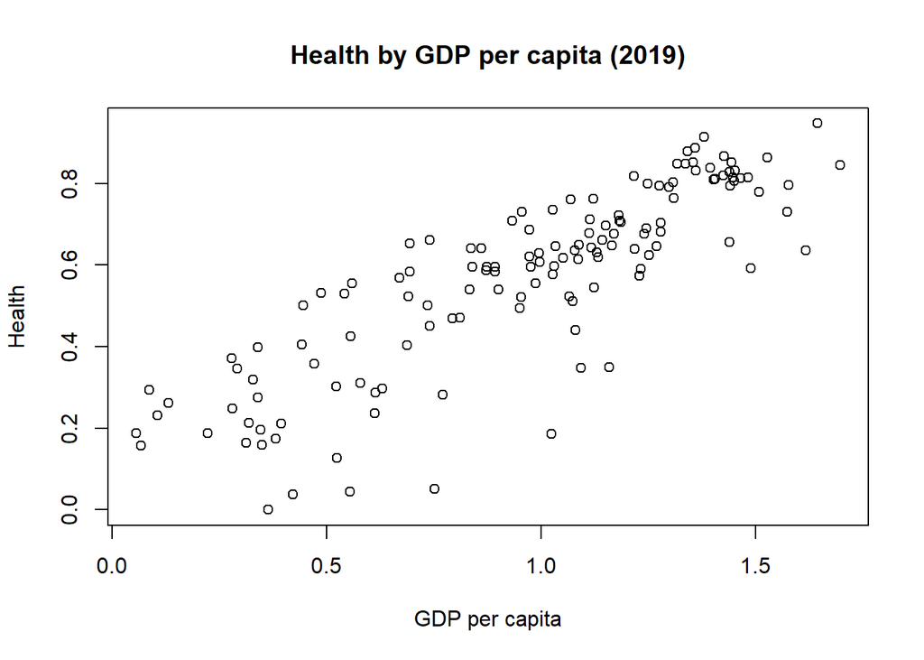

```r
plot(data_2019$gdp_per_capita, data_2019$health, xlab='GDP per capita',
     ylab='Health', main='Health by GDP per capita (2019)')
```

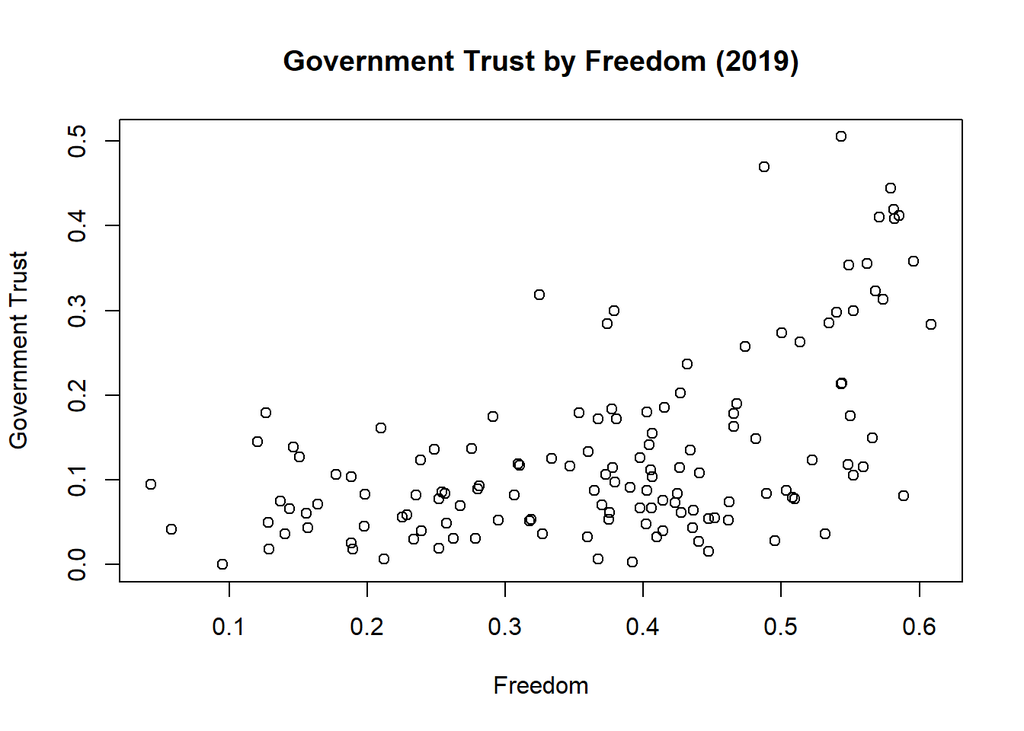

```r
plot(data_2019$freedom, data_2019$government_trust, xlab='Freedom',
     ylab='Government Trust', main='Government Trust by Freedom (2019)')
```

## 2. Simple Linear Regression Models

### a. Evaluation of variables relations

For this report, the two variables of interest for linear regression are: **GDP per capita** and **happiness score**.

```r
# Correlation coefficient
cor(data_2019$gdp_per_capita, data_2019$happiness_score)
```

```
## [1] 0.8194389
```

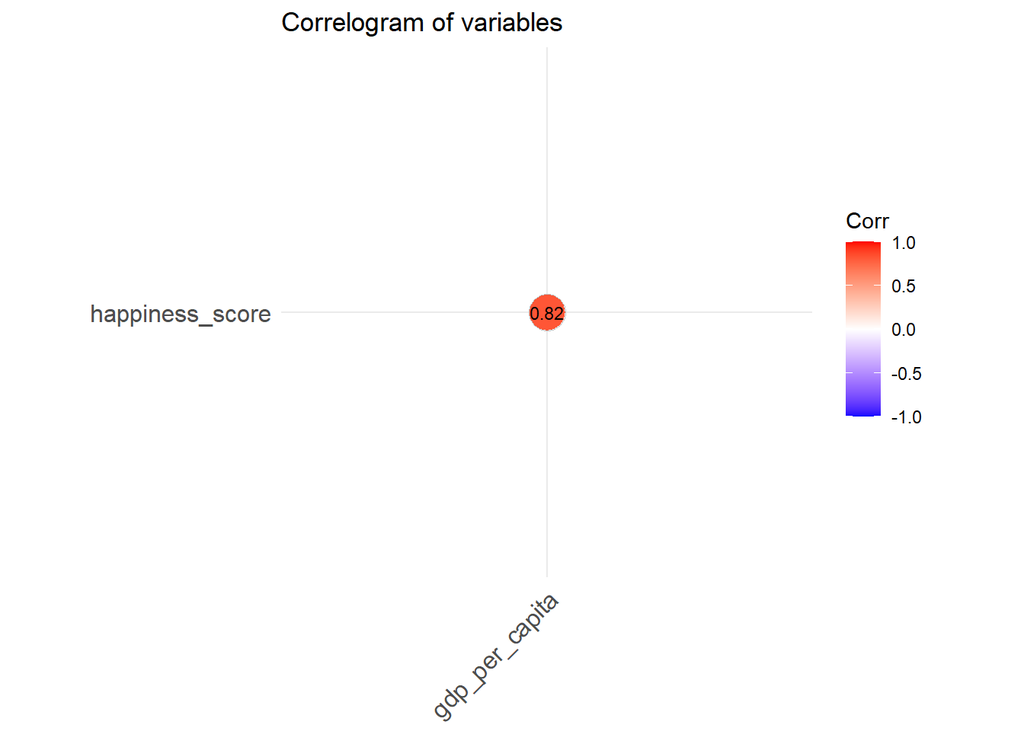

```r
# correlation plot of selected variables
library(ggcorrplot)
lin <- data_2019[,c(2,3)]

ggcorrplot(cor(lin), hc.order = TRUE, type = "lower", lab = TRUE, lab_size = 3, method="circle", colors = c("blue", "white", "red"), outline.color = "gray", show.legend = TRUE, show.diag = FALSE, title="Correlogram of variables")
```

It can be noted above that there is a strong correlation between the GDP per capita and the happiness score.

### b. Model Definition

```r
# splitting the data
split_2019 <- sample.split(data_2019$happiness_score, SplitRatio = 0.8)
training_set <- subset(data_2019, split_2019 == TRUE)
test_set <- subset(data_2019, split_2019 == FALSE)
```

```r
# fitting the data into linear regression model
lm_2019 <- lm(happiness_score ~ gdp_per_capita, data=training_set)
```

```r
# printing out the intercept and slope of the linear regression model
coef(lm_2019)
```

```
##    (Intercept) gdp_per_capita
##       3.252749       2.265749
```

```r
# summary of the linear regression model
summary(lm_2019)
```

```
##
## Call:
## lm(formula = happiness_score ~ gdp_per_capita, data = training_set)
##
## Residuals:
##      Min       1Q   Median       3Q      Max
## -1.75807 -0.47613 -0.04641  0.58884  1.41264
##
## Coefficients:
##                Estimate Std. Error t value Pr(>|t|)
## (Intercept)      3.2527     0.1745   18.64   <2e-16 ***
## gdp_per_capita   2.2657     0.1628   13.92   <2e-16 ***
## ---
## Signif. codes:  0 '***' 0.001 '**' 0.01 '*' 0.05 '.' 0.1 ' ' 1
##
## Residual standard error: 0.6833 on 108 degrees of freedom
## Multiple R-squared:  0.642,  Adjusted R-squared:  0.6387
## F-statistic: 193.7 on 1 and 108 DF,  p-value: < 2.2e-16
```

### c. Statistical Inference

A correlation test is conducted below to test the relationship between the variables: **gdp_per_capita** and **happiness_score**

```r
# correlation test using Pearson correlation test
cor.test(data_2019$gdp_per_capita, data_2019$happiness_score, method="pearson")
```

```
##
##  Pearson's product-moment correlation
##
## data:  data_2019$gdp_per_capita and data_2019$happiness_score
## t = 16.673, df = 136, p-value < 2.2e-16
## alternative hypothesis: true correlation is not equal to 0
## 95 percent confidence interval:
##  0.7558318 0.8677243
## sample estimates:
##       cor
## 0.8194389
```

The results show that the p-value is less than the significance level (0.05), so the null hypothesis (true correlation is equal to 0) is rejected. The alternative hypothesis (true correlation is not equal to 0) is not rejected, so this indicates that the two variables are significantly correlated. This is backed by the correlation coefficient which is approximately 0.82, which signifies a strong positive correlation between gdp_per_capita and happiness_score.

### d. Prediction

```r
# using the simple linear regression to predict the happiness score using the test set
ypred <- predict(lm_2019, newdata = test_set)

ypred
```

```
##       16       18       24       28       34       39       42       45
## 5.716841 6.613783 5.933266 5.929890 6.294584 5.821360 6.088152 6.322725
##       49       58       63       65       72       90       91       97
## 4.820126 5.700143 5.277716 6.152092 5.798839 4.956954 4.825835 4.480263
##      104      108      110      115      116      120      121      127
## 4.930218 4.436988 4.682595 5.774663 4.643715 3.961747 4.025301 3.977675
##      128      129      136      138
## 4.039394 4.565501 4.118876 3.407522
```

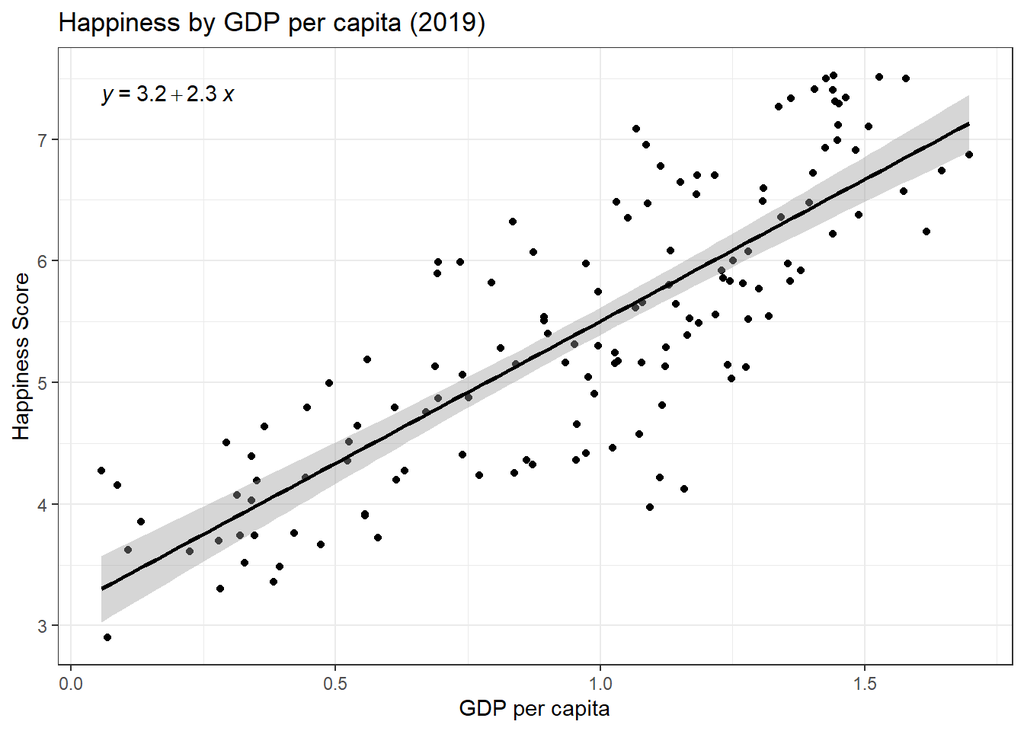

```r
# linear regression graph (whole data set)
happiness_graph <- ggplot(data_2019, aes(x=gdp_per_capita, y=happiness_score)) + geom_point()

happiness_graph <- happiness_graph + geom_smooth(method="lm", col="black")

happiness_graph <- happiness_graph + stat_regline_equation()

happiness_graph <- happiness_graph + theme_bw() + labs(
  title="Happiness by GDP per capita (2019)",
  x = "GDP per capita",
  y = "Happiness Score")

happiness_graph
```

## 3. Multiple Linear Regression

### a. Evaluation of variables

```r
# correlation matrix of selected variables
num_data1 <- data_2019[, c(2, 3, 4, 5, 6)]
cor(num_data1)
```

```
##                 happiness_score gdp_per_capita    family    health   freedom
## happiness_score       1.0000000      0.8194389 0.7408680 0.7961329 0.5423037
## gdp_per_capita        0.8194389      1.0000000 0.6739276 0.8460739 0.3712872
## family                0.7408680      0.6739276 1.0000000 0.5928802 0.4748750
## health                0.7961329      0.8460739 0.5928802 1.0000000 0.3427409
## freedom               0.5423037      0.3712872 0.4748750 0.3427409 1.0000000
```

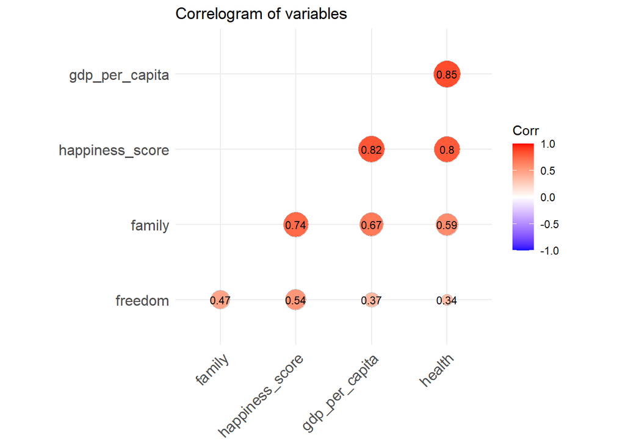

```r
# correlation plot of selected variables
ggcorrplot(cor(num_data1), hc.order = TRUE, type = "lower", lab = TRUE, lab_size = 3, method="circle", colors = c("blue", "white", "red"), outline.color = "gray", show.legend = TRUE, show.diag = FALSE, title="Correlogram of variables")
```

Scatter plots showing relationship between the selected variables

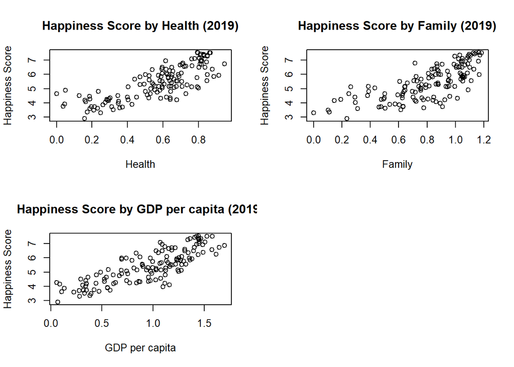

```r
par(mfrow=c(2,2))
plot(data_2019$health, data_2019$happiness_score, xlab='Health',
     ylab='Happiness Score', main='Happiness Score by Health (2019)')

plot(data_2019$family, data_2019$happiness_score, xlab='Family',
     ylab='Happiness Score', main='Happiness Score by Family (2019)')

plot(data_2019$gdp_per_capita, data_2019$happiness_score, xlab='GDP per capita',
     ylab='Happiness Score', main='Happiness Score by GDP per capita (2019)')
```

### b. Summary form Evaluation of Variables

```r
# summary of the selected variables
summary(num_data1)
```

```
##  happiness_score gdp_per_capita        family           health
##  Min.   :2.905   Min.   :0.05661   Min.   :0.0000   Min.   :0.0000
##  1st Qu.:4.407   1st Qu.:0.67472   1st Qu.:0.6423   1st Qu.:0.4097
##  Median :5.351   Median :1.03235   Median :0.8609   Median :0.6161
##  Mean   :5.409   Mean   :0.95958   Mean   :0.8052   Mean   :0.5668
##  3rd Qu.:6.347   3rd Qu.:1.27435   3rd Qu.:1.0326   3rd Qu.:0.7300
##  Max.   :7.526   Max.   :1.69752   Max.   :1.1833   Max.   :0.9472
##     freedom
##  Min.   :0.0432
##  1st Qu.:0.2587
##  Median :0.3913
##  Mean   :0.3719
##  3rd Qu.:0.4722
##  Max.   :0.6085
```

```r
# fitting the data into the multiple linear regression model
multiple_lm_2019 <- lm(happiness_score ~ gdp_per_capita + health + family + freedom, data = training_set)
```

```r
# summary of the multiple linear regression model
summary(multiple_lm_2019)
```

```
##
## Call:
## lm(formula = happiness_score ~ gdp_per_capita + health + family +
##     freedom, data = training_set)
##
## Residuals:
##     Min      1Q  Median      3Q     Max
## -1.3743 -0.2442 -0.0069  0.3598  1.2485
##
## Coefficients:
##                Estimate Std. Error t value Pr(>|t|)
## (Intercept)      2.0748     0.1917  10.825  < 2e-16 ***
## gdp_per_capita   0.7752     0.2474   3.134  0.00224 **
## health           1.7937     0.4228   4.242 4.78e-05 ***
## family           1.1823     0.2839   4.164 6.42e-05 ***
## freedom          1.6636     0.4138   4.020  0.00011 ***
## ---
## Signif. codes:  0 '***' 0.001 '**' 0.01 '*' 0.05 '.' 0.1 ' ' 1
##
## Residual standard error: 0.528 on 105 degrees of freedom
## Multiple R-squared:  0.7922, Adjusted R-squared:  0.7843
## F-statistic: 100.1 on 4 and 105 DF,  p-value: < 2.2e-16
```

```r
# using the multiple linear regression to predict the happiness score using the test set
ypred <- predict(multiple_lm_2019, newdata = test_set)

ypred
```

```
##       16       18       24       28       34       39       42       45
## 5.920889 6.957662 6.245918 6.409816 6.652124 5.615562 5.853652 6.196455
##       49       58       63       65       72       90       91       97
## 4.951504 5.551293 5.896149 6.222229 5.410347 3.975489 4.999141 4.399626
##      104      108      110      115      116      120      121      127
## 4.473525 4.597180 4.361564 5.601053 4.270207 4.089584 3.382639 4.005507
##      128      129      136      138
## 4.497894 4.022865 3.086081 2.759257
```